# Bovine Spongiform Encephalopathy Surveillance Statistics in United Kingdom and a Shiny App for Raman Spectra Analysis

Shaowei Ding

Ag & Biosystems Engineering

STAT 585X

**Background**  
Bovine Spongiform Encephalopathy(BSE), or the so called “Mad Cow” disease,is a kind of prion related disease, which is fatal and trigger neurological dysfunction in Cattles. Prions are neither bacteria nor viruses, with no genetic informaiton, but still causes disease. It has long invubation period and progess inexorably once clinical conditions occur.(Araujo,2013) BSE can be transmitted by eating food containing brain,spinal cord or other nervous system tissue fro an infected animal, and prions begin to slowly transform normal protein into the abonormal prion shape, which eventually leads to fatal damage to the nervous system.The human form of BSE is called Creutzfeldt-Jakob Disease(CJD).BSE can cause death usually within one year of onset of illness. Currently disease diagnosis is still limited, and there isn't mature technique that can detect BSE at a earlier stage. Diseased animals have protein transformation in the central nervous system. Since retina is a derivative of forebrain, it is the most exposed portion of the central nervous system. Raman spectroscopy is a kind of non-invasive and non-destructive technique and can be used to measure unique fingerprint for different disease. And by applying this spectroscopy in retina, the most exposed nervous tissue; it is highly possible that BSE can be diagnosed accurately and at earlier stage.  
**Motivation** Bovine Spongiform Encephalopathy disease was first found in the mid-1980s from 16 cattle, and that number dramatically increased to over 190,000 cases worldwide, with the majority of them in Europe.(Lee et al., 2013) ,Which led to a disaster to human, the agricultural industry and the food industry. The worst case of BSE was happened in the United Kingdom, and in this analysis, we will take a close look at the developent of BSE in the United Kingdom.Since the research I am doing is about BSE diagnosis, and I think it is interesting to look at the history of this disease. Moreover, by inverstingating this case, it makes people have a better awareness of the importance of food safety.

**Data Collecting**  
These data is obtained from Animal Health and Veterinary Laboratories Agency,“[http://www.defra.gov.uk/ahvla-en/publication/tse-stats-cattle/”.BSE](http://www.defra.gov.uk/ahvla-en/publication/tse-stats-cattle/%22.BSE) cases in every year/every month is available, and it is also catagorized into active and passive surveillance. Also the birth date and age of all suspected animals are recorded. Four pdfs have data from before year 1987 to 2014, and then I converted them to csv format.Additionally, I downloaded the UK shape file, which can be used to plot the distribution of BSE.Since the name of every city in two files don't match, I need to do some modification to plot the map.

**Required Packages**

library(reshape)  
library(ggplot2)  
library(knitr)  
library(maptools)  
library(plyr)  
install.packages(“Mcow”)

**Possible questions that could be answered**

1. What is the overall trending of BSE from 1987 to 2014? What is the trending of passive Surveillance and active surveillance?
2. What are the locations of BSE?
3. What is the percent reduction year on year?
4. How many confirmed cases of BSE per million head of cattle population over 24 months of age?
5. What is the trending of BSE by comfirmed cases of BSE in the UK by year of birth and age?
6. On August 1st, 1996, extra control measures on animal feed containing mammalian meat and bone meal are considered to have been fully implemented, and what is trending of BSE after this date?

**trend of passive and active surveillance in united kingdom**  
First let's take a look at the general trend of BSE cases from 1987 to 2014 based on passive and active surveillance.

```r
library(reshape)
```

```
## ymax not defined: adjusting position using y instead
```

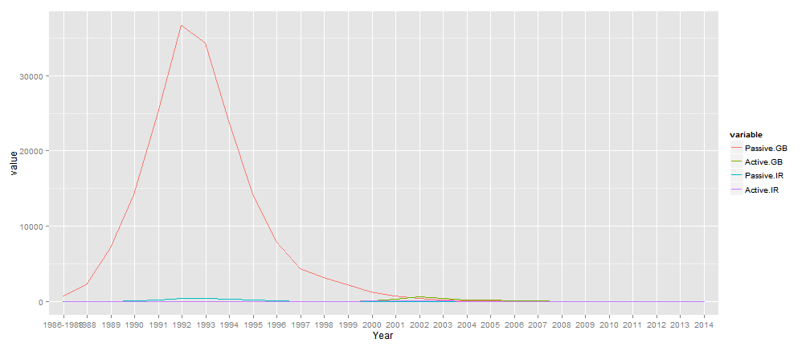

```r
library(ggplot2)
pa <- read.csv("passive and active.csv")
pa$Year <- as.character(pa$Year)
pa$Year[pa$Year == "Pre 1988"] <- "1986-1988"
a.melt <- melt(pa[1:28, c(1:3, 5:6)], id = c("Year"))
pd <- position_dodge(0.1)
ggplot(data = a.melt, aes(x = Year, y = value, colour = variable)) + geom_line(position = pd,
    aes(group = variable))
```

This plot shows the majority of data is from the passive surveillance in great britain, and BSE cases were the most from 1989-1996.Now we can take a look at great britain.

**trend of passive surveillance in great britain**

```r
overall <- read.csv("OVERALL.csv")
trend <- overall[1:28, ]
trend.det <- melt(trend)
```

```
## ymax not defined: adjusting position using y instead
```

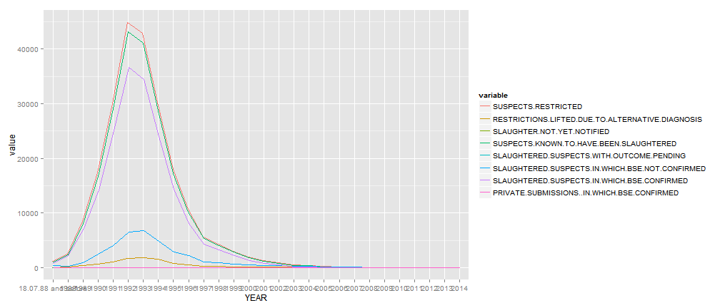

```r
pd <- position_dodge(0.1)
ggplot(data = trend.det, aes(x = YEAR, y = value, colour = variable)) + geom_line(position = pd,
    aes(group = variable))
```

This plot shows the trend of restricted case and confirmed case. They all follow the similar curve, but the amplitude is different. The amount of suspected cases is a lot and almost all of those animals were slaughtered. Among them, the purple curve represents the actual confirmed cases.

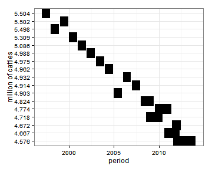

```r
library(reshape)
library(ggplot2)
library(Mcow)
age24 <- read.csv("millioncattle.csv")
age24 <- age24[c(1:75), -c(5, 8)]
colnames(age24) <- c("start", "end", "million of cattles", "# of case by date of confirmation",
    "# of case by date of restriction", "# per million by data of confirmation",
    "# per million by date of restriction")
age.sub <- age24[-1, ]
age.sub$name <- 1:74
# I couldn't run Mcow packages from a different computer, so I add this
# function in case the package wont be loaded in a different computer.
date <- function(x) {
    as.Date(x = paste("1-", x, sep = ""), format = "%d-%b-%y")
}
age.sub[, 1] <- date(age.sub[, 1])
age.sub[, 2] <- date(age.sub[, 2])
age.sub$"# per million by data of confirmation" <- as.numeric(as.character(age.sub$"# per million by data of confirmation"))
mdfr <- melt(age.sub, measure.vars = c("start", "end"))
mage <- melt(age.sub, measure.vars = c("start", "end"))
layout(t(1:2))
ggplot(mdfr, aes(mdfr$value, as.factor(mdfr$"million of cattles"))) + geom_line(size = 6) +
    xlab("period") + ylab("million of cattles") + theme_bw()
```

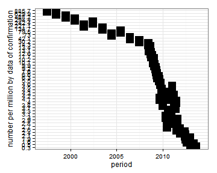

```r
ggplot(mage, aes(mage$value, as.factor(mage$"# per million by data of confirmation"))) +
    geom_line(size = 6) + xlab("period") + ylab("number per million by data of confirmation") +
    theme_bw()
```

[output not shown]

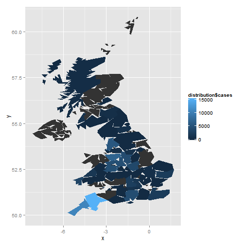

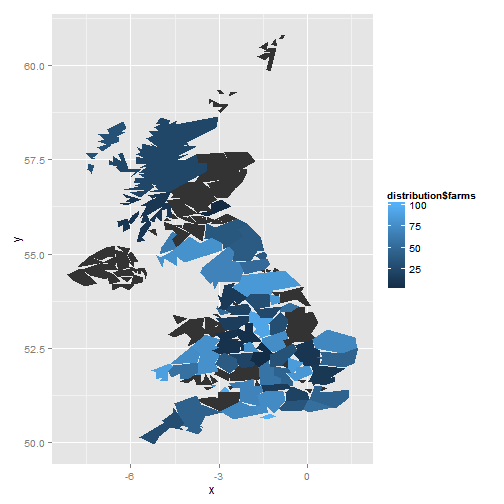

The color gradient indicates the distribution of BSE cases and farms where BSE cases have been found.

**Percent Reduction year on year**

```
## ymax not defined: adjusting position using y instead
```

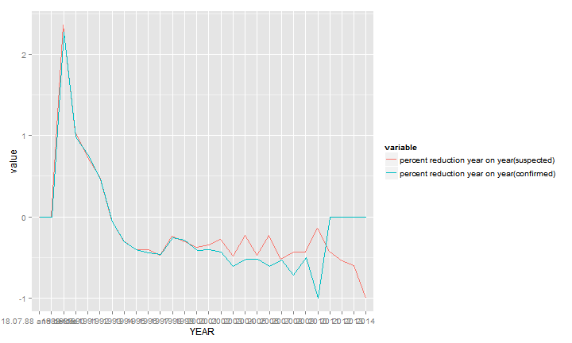

```r
# percent reduction head(trend)
red <- trend[, c(1, 2, 8)]
red$"percent reduction year on year(suspected)" <- NA
red$"percent reduction year on year(confirmed)" <- NA
i <- NA
j <- NA
per <- NA
red[1:28, 2:3] <- as.matrix(sapply(red[1:28, 2:3], as.numeric))
percent <- function(x, digits = 2, format = "f", ...) {
    paste(formatC(100 * x, format = format, digits = digits, ...), "%", sep = "")
}

for (i in 3:(length(red$SUSPECTS.RESTRICTED))) {
    red$"percent reduction year on year(suspected)"[i] <- as.numeric((-red$SUSPECTS.RESTRICTED[i -
        1] + red$SUSPECTS.RESTRICTED[i])/red$SUSPECTS.RESTRICTED[i - 1])
    red$"percent reduction year on year(confirmed)"[i] <- as.numeric((-red$SLAUGHTERED.SUSPECTS.IN.WHICH.BSE.CONFIRMED[i -
        1] + red$SLAUGHTERED.SUSPECTS.IN.WHICH.BSE.CONFIRMED[i])/red$SLAUGHTERED.SUSPECTS.IN.WHICH.BSE.CONFIRMED[i -
        1])
    if (red$SLAUGHTERED.SUSPECTS.IN.WHICH.BSE.CONFIRMED[i - 1] == 0) {
        red$"percent reduction year on year(confirmed)"[i] <- 0
    }
}

red.melt <- melt(red[, c(1, 4, 5)], id = c("YEAR"))
red.melt$value <- as.numeric(red.melt$value)
red.melt$value[is.na(red.melt$value)] <- 0
pd <- position_dodge(0.1)
ggplot(data = red.melt, aes(x = YEAR, y = value, colour = variable)) + geom_line(position = pd,
    aes(group = variable))
```

This plot shows the percentage reduction of confirmed and suspected cases year on year.

**the trend of different age in great britain (confirmed case)**

```r
age <- read.csv("age.gb.csv")
age <- age[-1, -2]
age$"Birth Period" <- 1982:2006
```

[output not shown]

```
## ymax not defined: adjusting position using y instead
```

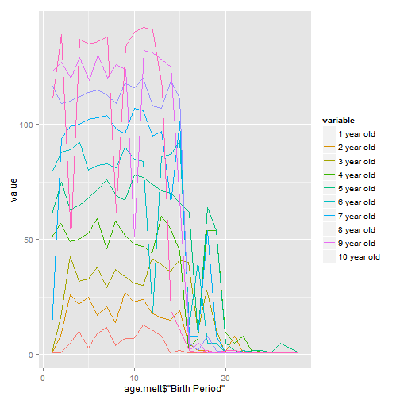

```r
colnames(age) <- c("Birth Period", "1 year old", "2 year old", "3 year old",
    "4 year old", "5 year old", "6 year old", "7 year old", "8 year old", "9 year old",
    "10 year old")
age.melt <- melt(age, id = "Birth Period")
age.melt$value <- as.numeric(age.melt$value)
age.melt$"Birth Period" <- as.numeric(age.melt$"Birth Period")
age.melt$variable <- as.factor(age.melt$variable)

pd <- position_dodge(0.1)
ggplot(data = age.melt, aes(x = age.melt$"Birth Period", y = value, colour = variable)) +
    geom_line(position = pd, aes(group = variable))
```

If we set age as a factor, age of cattles seems to be proportional to number of cases.

**In recent two years, the distribution of BSE cases in great britain**

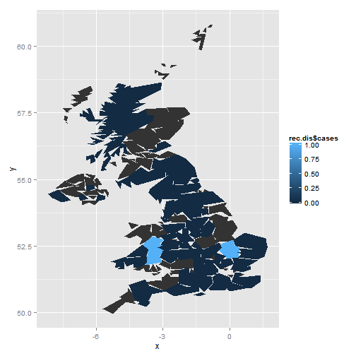

```r
recent <- read.csv("C:/Users/sding/Documents/GitHub/585xproject/recent.csv")
a <- recent[-1, c(1, 2, 3, 4)]
recent[, c(2, 3, 4)] <- as.matrix(sapply(recent[, c(2, 3, 4)], as.numeric))
a$cases <- rowSums(recent[-1, c(2, 3, 4)])
a$County <- gsub("&", "and", a$County)
a <- a[, -c(2, 3, 4)]
a$County[a$County == "North-West Wales"] <- "Ceredigion"
colnames(a) <- c("region", "cases")

rec.dis <- merge(oz.subset, a, by = "region")
rec.dis$cases <- as.numeric(rec.dis$cases)
ggplot() + geom_polygon(data = oz.subset, aes(x = x, y = y, order = order, group = group)) +
    geom_polygon(data = rec.dis, aes(x = x, y = y, order = order, group = group,
        fill = rec.dis$cases))
```

Even though BSE is no longer active in the UK, there are still cases appeared in recent years. Since prion disease is hard to diagnose  
and it spread easily through food contamination, attention is still required to monitor the development of BSE.

**A shiny App for Raman Spectra Analysis**  
It can be run from  
library(shiny)  
runGist(11195851)  
In the app, data is uploaded as required format and based on user's preferance, the desired plot will be displayed in the main panel.  
Additionally, the result can be downloaded from the buttion on the left. However, uploaded data need to be corrected by polynomial  
baseline correction, smoothing and normalization.

**Mcow Package**  
The packages I built for this project is consisted of 4 functions: data,extractPolygons(the function in class),percent and percentage_red  
uction. This is not quite complete, and some modifications need to be made.  
date: This function to reformat the date in the given dataset  
extractPolygons: The function to extract polygons  
percent: The function to format data into percentage format  
percent_reduction: This function to calculate percent reduction year on year

**Discussion and Conclusion**

From this analysis,BSE cases have been decreasing dramatically during the past decade, however, there are still BSE existing and more  
prion diseases like scrapie and CJDs appear, which threaten human and animal health. Since prion caused disease is very hard to  
diagnose, with the application of Raman Spectroscopy, people can dectect the protein transformation at a earlier stage, which is  
beneficial for diease control, as well leading to a better medical treatment.